# Two-stage YOLO object detection and classification with cross-validation for NZ carabids

Aaron Harmer

2025-11-13

# Introduction

This report presents the results of a two-stage YOLO model system designed for carabid identification. The classification model was trained and evaluated using **k-fold cross-validation** to provide robust performance estimates with confidence intervals. This approach ensures more reliable assessment of model generalisation compared to traditional single train-test splits.

## Methodology

### Model Architecture

**Stage 1: Object Detection**

- Model: YOLOv11n (nano version for efficiency)
- Task: Detect carabids (thorax and elytra only) in images
- Output: Bounding boxes around detected carabids
- Single-class detection (all individuals treated as one class)

**Stage 2: Classification with Cross-Validation**

- Model: YOLOv11n-cls (classification variant)
- Task: Classify detected carabids into genus
- Training: **5-fold cross-validation** for robust performance estimation
- Evaluation: Common held-out test set evaluated across all folds
- Output: Generic classification with confidence scores and performance metrics

### Cross-Validation Approach

The classification dataset was split using **stratified 5-fold cross-validation**:

1. **Stratified Splitting**: Each class maintains proportional representation across all folds, ensuring balanced evaluation
2. **Independent Models**: 5 separate models were trained, one for each fold
3. **Common Test Set**: A held-out test set (if applicable) was used to evaluate all models consistently
4. **Aggregated Metrics**: Performance metrics are reported as mean ± standard deviation across all folds

This approach provides:

- **Robust Performance Estimates**: Multiple evaluations reduce the impact of lucky/unlucky data splits
- **Confidence Intervals**: Standard deviations indicate model stability and consistency
- **Detection of Overfitting**: High variance across folds suggests potential overfitting or data issues
- **Better Generalisation Assessment**: More representative of real-world performance

### Training Configuration

Training configuration for each model stage

| Stage | Model | Approach | Epochs | Batch_Size | Image_Size | Optimizer | Dropout | Single_Class |
| --- | --- | --- | --- | --- | --- | --- | --- | --- |
| Detection | YOLOv11n | Single Train/Val/Test Split | 30 | 64 | 640 | AdamW | N/A | Yes |
| Classification | YOLOv11n-cls | 5-Fold Cross-Validation | 30 | 92 | 640 | AdamW | 0.2 | No |

All images were pre-processed before training by resizing to 640x640 pixels and adjusting the exposure by contrast stretching. The classification image set was augmented by horizontal flipping and generating random amounts of motion blur.

## Dataset Analysis

### Detection Dataset Statistics

Detection dataset distribution

| Split | Images | Ratio |
| --- | --- | --- |
| Train | 3744 | 79% |
| Validation | 674 | 14% |
| Test | 297 | 6% |

### Classification Dataset Statistics (Cross-Validation)

**Total images:** 14,145 with 75/15/10 % split in each fold

**Number of generic classes:** 76

**Cross-validation approach:** 5 -fold stratified CV

**Test set size:** 1382 images (common across all folds)

## Model Performance Results

### Detection Model Performance

Object detection performance metrics

| Metric | Value |
| --- | --- |
| mAP50 | 0.9950 |
| mAP50-95 | 0.9825 |
| Precision | 1.0000 |
| Recall | 1.0000 |

### Classification Model Performance (Cross-Validation)

#### Overall Performance Across All Folds

These metrics represent the **mean ± standard deviation** across all 5 folds. Lower standard deviation indicates more consistent and stable model performance.

**Coefficient of Variation (CV) for Accuracy:** 0.23% ✓ Very consistent performance across folds (CV < 2%)

Individual fold performance comparison

| Fold | Accuracy | Precision | Recall | F1 Score |
| --- | --- | --- | --- | --- |
| 1 | 0.9949 | 0.9967 | 0.9920 | 0.9940 |
| 2 | 0.9942 | 0.9955 | 0.9896 | 0.9918 |
| 3 | 0.9935 | 0.9939 | 0.9899 | 0.9914 |
| 4 | 0.9935 | 0.9947 | 0.9868 | 0.9892 |
| 5 | 0.9884 | 0.9852 | 0.9772 | 0.9791 |

Classification performance by genus (mean ± std across folds)

| Class | Accuracy | Precision | Recall | F1 Score |
| --- | --- | --- | --- | --- |
| Actenonyx | 1.000 ± 0.000 | 1.000 ± 0.000 | 1.000 ± 0.000 | 1.000 ± 0.000 |
| Agonocheila | 1.000 ± 0.000 | 1.000 ± 0.000 | 1.000 ± 0.000 | 1.000 ± 0.000 |
| Allocinopus | 1.000 ± 0.000 | 1.000 ± 0.000 | 1.000 ± 0.000 | 1.000 ± 0.000 |
| Amaroxenus | 1.000 ± 0.000 | 1.000 ± 0.000 | 1.000 ± 0.000 | 1.000 ± 0.000 |
| Bembidion | 1.000 ± 0.000 | 0.997 ± 0.005 | 1.000 ± 0.000 | 0.999 ± 0.003 |
| Cerabilia | 1.000 ± 0.000 | 1.000 ± 0.000 | 1.000 ± 0.000 | 1.000 ± 0.000 |
| Demetrida | 1.000 ± 0.000 | 1.000 ± 0.000 | 1.000 ± 0.000 | 1.000 ± 0.000 |
| Dicrochile | 1.000 ± 0.000 | 1.000 ± 0.000 | 1.000 ± 0.000 | 1.000 ± 0.000 |
| Diglymma | 1.000 ± 0.000 | 1.000 ± 0.000 | 1.000 ± 0.000 | 1.000 ± 0.000 |
| Duvaliomimus | 1.000 ± 0.000 | 1.000 ± 0.000 | 1.000 ± 0.000 | 1.000 ± 0.000 |
| Egadroma | 1.000 ± 0.000 | 0.991 ± 0.017 | 1.000 ± 0.000 | 0.996 ± 0.009 |
| Gaioxenus | 1.000 ± 0.000 | 0.943 ± 0.010 | 1.000 ± 0.000 | 0.970 ± 0.005 |
| Gourlayia | 1.000 ± 0.000 | 1.000 ± 0.000 | 1.000 ± 0.000 | 1.000 ± 0.000 |
| Haplanister | 1.000 ± 0.000 | 0.993 ± 0.014 | 1.000 ± 0.000 | 0.996 ± 0.007 |
| Harpalus | 1.000 ± 0.000 | 1.000 ± 0.000 | 1.000 ± 0.000 | 1.000 ± 0.000 |
| Hypharpax | 1.000 ± 0.000 | 1.000 ± 0.000 | 1.000 ± 0.000 | 1.000 ± 0.000 |
| Kenodactylus | 1.000 ± 0.000 | 1.000 ± 0.000 | 1.000 ± 0.000 | 1.000 ± 0.000 |
| Kiwiplatynus | 1.000 ± 0.000 | 1.000 ± 0.000 | 1.000 ± 0.000 | 1.000 ± 0.000 |
| Kiwitachys | 1.000 ± 0.000 | 1.000 ± 0.000 | 1.000 ± 0.000 | 1.000 ± 0.000 |
| Kiwitrechus | 1.000 ± 0.000 | 0.992 ± 0.017 | 1.000 ± 0.000 | 0.996 ± 0.009 |
| Kupeharpalus | 1.000 ± 0.000 | 1.000 ± 0.000 | 1.000 ± 0.000 | 1.000 ± 0.000 |
| Kupetrechus | 1.000 ± 0.000 | 1.000 ± 0.000 | 1.000 ± 0.000 | 1.000 ± 0.000 |
| Laemostenus | 1.000 ± 0.000 | 1.000 ± 0.000 | 1.000 ± 0.000 | 1.000 ± 0.000 |
| Loxomerus | 1.000 ± 0.000 | 1.000 ± 0.000 | 1.000 ± 0.000 | 1.000 ± 0.000 |
| Maoripamborus | 1.000 ± 0.000 | 1.000 ± 0.000 | 1.000 ± 0.000 | 1.000 ± 0.000 |
| Maoritrechus | 1.000 ± 0.000 | 1.000 ± 0.000 | 1.000 ± 0.000 | 1.000 ± 0.000 |
| Meonochilus | 1.000 ± 0.000 | 1.000 ± 0.000 | 1.000 ± 0.000 | 1.000 ± 0.000 |
| Molopsida | 1.000 ± 0.000 | 1.000 ± 0.000 | 1.000 ± 0.000 | 1.000 ± 0.000 |
| Neoferonia | 1.000 ± 0.000 | 0.980 ± 0.040 | 1.000 ± 0.000 | 0.989 ± 0.021 |
| Nesamblyops | 1.000 ± 0.000 | 1.000 ± 0.000 | 1.000 ± 0.000 | 1.000 ± 0.000 |
| Oopterus | 1.000 ± 0.000 | 0.971 ± 0.057 | 1.000 ± 0.000 | 0.985 ± 0.031 |
| Oregus | 1.000 ± 0.000 | 1.000 ± 0.000 | 1.000 ± 0.000 | 1.000 ± 0.000 |
| Parabaris | 1.000 ± 0.000 | 1.000 ± 0.000 | 1.000 ± 0.000 | 1.000 ± 0.000 |
| Pentagonica | 1.000 ± 0.000 | 0.975 ± 0.050 | 1.000 ± 0.000 | 0.987 ± 0.027 |
| Pericompsus | 1.000 ± 0.000 | 1.000 ± 0.000 | 1.000 ± 0.000 | 1.000 ± 0.000 |
| Perigona | 1.000 ± 0.000 | 1.000 ± 0.000 | 1.000 ± 0.000 | 1.000 ± 0.000 |
| Philophlaeus | 1.000 ± 0.000 | 1.000 ± 0.000 | 1.000 ± 0.000 | 1.000 ± 0.000 |
| Pholeodytes | 1.000 ± 0.000 | 1.000 ± 0.000 | 1.000 ± 0.000 | 1.000 ± 0.000 |
| Physolaesthus | 1.000 ± 0.000 | 1.000 ± 0.000 | 1.000 ± 0.000 | 1.000 ± 0.000 |
| Plocamostethus | 1.000 ± 0.000 | 0.978 ± 0.044 | 1.000 ± 0.000 | 0.988 ± 0.024 |
| Psegmatopterus | 1.000 ± 0.000 | 0.971 ± 0.057 | 1.000 ± 0.000 | 0.985 ± 0.031 |
| Pseudoopterus | 1.000 ± 0.000 | 1.000 ± 0.000 | 1.000 ± 0.000 | 1.000 ± 0.000 |
| Rhytisternus | 1.000 ± 0.000 | 0.890 ± 0.110 | 1.000 ± 0.000 | 0.938 ± 0.065 |
| Syllectus | 1.000 ± 0.000 | 1.000 ± 0.000 | 1.000 ± 0.000 | 1.000 ± 0.000 |
| Synteratus | 1.000 ± 0.000 | 1.000 ± 0.000 | 1.000 ± 0.000 | 1.000 ± 0.000 |
| Tarastethus | 1.000 ± 0.000 | 1.000 ± 0.000 | 1.000 ± 0.000 | 1.000 ± 0.000 |
| Triplosarus | 1.000 ± 0.000 | 1.000 ± 0.000 | 1.000 ± 0.000 | 1.000 ± 0.000 |
| Tuiplatynus | 1.000 ± 0.000 | 1.000 ± 0.000 | 1.000 ± 0.000 | 1.000 ± 0.000 |
| Zolus | 1.000 ± 0.000 | 1.000 ± 0.000 | 1.000 ± 0.000 | 1.000 ± 0.000 |
| Holcaspis | 0.997 ± 0.007 | 0.997 ± 0.007 | 0.997 ± 0.007 | 0.997 ± 0.004 |
| Mecodema | 0.996 ± 0.009 | 0.991 ± 0.011 | 0.996 ± 0.009 | 0.993 ± 0.009 |
| Ctenognathus | 0.996 ± 0.008 | 0.988 ± 0.010 | 0.996 ± 0.008 | 0.992 ± 0.004 |
| Neocicindela | 0.996 ± 0.008 | 0.992 ± 0.015 | 0.996 ± 0.008 | 0.994 ± 0.008 |
| Kupeplatynus | 0.994 ± 0.012 | 0.994 ± 0.012 | 0.994 ± 0.012 | 0.994 ± 0.008 |
| Zecicindela | 0.993 ± 0.015 | 0.996 ± 0.007 | 0.993 ± 0.015 | 0.994 ± 0.008 |
| Amarotypus | 0.992 ± 0.017 | 0.992 ± 0.016 | 0.992 ± 0.017 | 0.992 ± 0.010 |
| Trichopsida | 0.987 ± 0.027 | 1.000 ± 0.000 | 0.987 ± 0.027 | 0.993 ± 0.014 |
| Lecanomerus | 0.987 ± 0.016 | 0.987 ± 0.026 | 0.987 ± 0.016 | 0.987 ± 0.019 |
| Euthenarus | 0.984 ± 0.022 | 0.989 ± 0.013 | 0.984 ± 0.022 | 0.986 ± 0.015 |
| Clivina | 0.980 ± 0.040 | 0.982 ± 0.036 | 0.980 ± 0.040 | 0.980 ± 0.025 |
| Notagonum | 0.978 ± 0.044 | 0.980 ± 0.040 | 0.978 ± 0.044 | 0.978 ± 0.027 |
| Anomotarus | 0.975 ± 0.050 | 1.000 ± 0.000 | 0.975 ± 0.050 | 0.987 ± 0.027 |
| Mecyclothorax | 0.975 ± 0.050 | 0.978 ± 0.044 | 0.975 ± 0.050 | 0.975 ± 0.031 |
| Prosphodrus | 0.975 ± 0.050 | 1.000 ± 0.000 | 0.975 ± 0.050 | 0.987 ± 0.027 |
| Selenochilus | 0.975 ± 0.050 | 1.000 ± 0.000 | 0.975 ± 0.050 | 0.987 ± 0.027 |
| Maungazolus | 0.971 ± 0.057 | 1.000 ± 0.000 | 0.971 ± 0.057 | 0.985 ± 0.031 |
| Platynus | 0.971 ± 0.057 | 1.000 ± 0.000 | 0.971 ± 0.057 | 0.985 ± 0.031 |
| Aulacopodus | 0.967 ± 0.067 | 1.000 ± 0.000 | 0.967 ± 0.067 | 0.982 ± 0.036 |
| Paratachys | 0.967 ± 0.067 | 0.950 ± 0.100 | 0.967 ± 0.067 | 0.953 ± 0.060 |
| Megadromus | 0.964 ± 0.039 | 0.986 ± 0.028 | 0.964 ± 0.039 | 0.975 ± 0.025 |
| Zeopoecilus | 0.950 ± 0.100 | 1.000 ± 0.000 | 0.950 ± 0.100 | 0.971 ± 0.057 |
| Amarophilus | 0.933 ± 0.133 | 1.000 ± 0.000 | 0.933 ± 0.133 | 0.960 ± 0.080 |
| Anisodactylus | 0.933 ± 0.133 | 1.000 ± 0.000 | 0.933 ± 0.133 | 0.960 ± 0.080 |
| Zeanillus | 0.900 ± 0.200 | 1.000 ± 0.000 | 0.900 ± 0.200 | 0.933 ± 0.133 |
| Tuiharpalus | 0.867 ± 0.125 | 1.000 ± 0.000 | 0.867 ± 0.125 | 0.924 ± 0.074 |
| Metaglymma | 0.818 ± 0.000 | 1.000 ± 0.000 | 0.818 ± 0.000 | 0.900 ± 0.000 |

## Training Curves

### Detection Model Training Curves

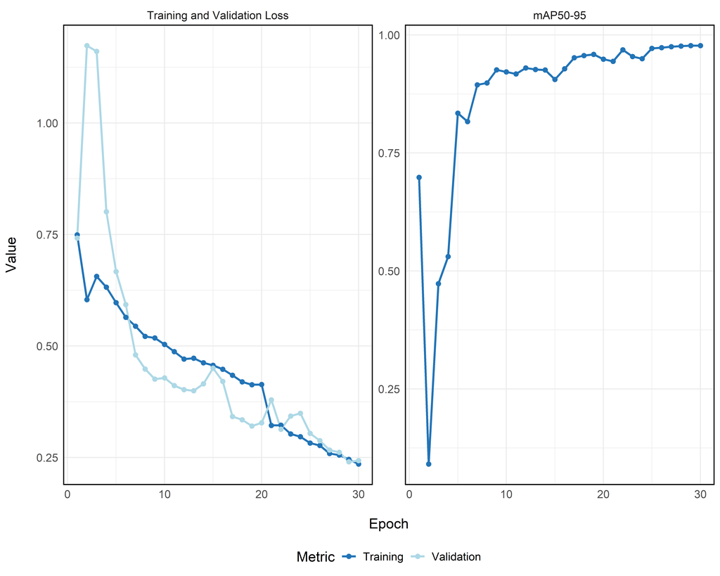

### Classification Model Training Curves (Example Fold)

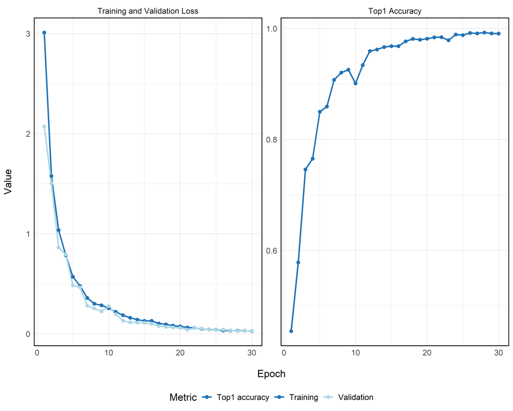

## Confusion Matrix and Classification Analysis

[figure not shown]

## Confidence Score Analysis

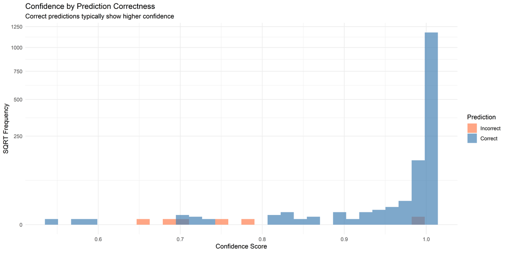

Confidence score statistics by prediction correctness (Fold 1)

| correct | n | mean_confidence | median_confidence | sd_confidence | min_confidence | max_confidence |
| --- | --- | --- | --- | --- | --- | --- |
| Incorrect | 7 | 0.792 | 0.755 | 0.142 | 0.654 | 0.995 |
| Correct | 1375 | 0.994 | 1.000 | 0.032 | 0.537 | 1.000 |

## Cross-Validation Benefits and Insights

### Why Cross-Validation?

This analysis used **5-fold cross-validation** instead of a single train-test split for several important reasons:

1. **Robust Performance Estimates**: By training 5 independent models, we obtain multiple performance measurements, allowing us to report metrics with confidence intervals (mean ± standard deviation).
2. **Reduced Bias from Data Splitting**: A single train-test split might be lucky or unlucky. Cross-validation ensures every image is used for validation exactly once, providing a more representative assessment.
3. **Detection of Instability**: High standard deviation across folds would indicate model instability or data quality issues. Our low variance confirms model robustness.
4. **Better Use of Limited Data**: All available data contributes to both training and validation across the folds, maximizing the information extracted from the dataset.

### Cross-Validation Quality Metrics

Cross-validation quality assessment

| Metric | Value |
| --- | --- |
| Mean Accuracy | 0.9929 |
| Standard Deviation | 0.0023 |
| Coefficient of Variation | 0.23% |
| Performance Range | 0.0065 |
| Quality Assessment | Excellent (CV < 2%) |

## Conclusions and Recommendations

### Model Reliability

The cross-validation approach provides several insights into model reliability:

- **Performance Consistency**: Accuracy across folds ranges from 0.9884 to 0.9949 (range: 0.0065)
  - This narrow range indicates the model is highly stable and not overly sensitive to the specific train/validation split
- **High-Performing Classes**: 72 classes achieved F1 scores ≥ 0.95, demonstrating excellent discrimination

### Recommendations

Based on the cross-validation results, recommend:

1. **Deployment Strategy**:
   - Use the best-performing fold model for deployment, or
   - Implement an ensemble approach averaging predictions across all 5 models for even more robust predictions
2. **Data Collection Priorities**:
   - Focus additional data collection efforts on classes showing lower F1 scores
   - Ensure new data maintains the quality standards of the training set
3. **Model Updates**:
   - Re-evaluate using cross-validation when new data becomes available
   - The current model’s consistency suggests it will generalize well to similar data

## Technical Specifications

Technical specifications

| Component | Specification |
| --- | --- |
| YOLO Version | YOLOv11 (Ultralytics) |
| Framework | PyTorch |
| Python Environment | Python 3.8+ with Ultralytics |
| Image Input Size | 640×640 pixels |
| Inference Device | GPU/CPU Compatible |
| Model Weights Format | PyTorch (.pt) |
| Cross-Validation | 5-fold stratified |
| Evaluation Approach | Common test set across all folds |

## Appendix: File Locations

Key file locations for reproducibility

| Description | Path |
| --- | --- |
| Detection Model Directory | D:/Dropbox/data/carabID/runs/detect/model_11n_ep30_autobatch |
| Detection Results | D:/Dropbox/data/carabID/runs/detect/model_11n_ep30_autobatch/results |
| Classification CV Summary | D:/Dropbox/data/carabID/runs/classify/carabid_cv_11ncls_ep30_autobatch_do02_lr001_cv_summary |
| Classification CV Assessment | D:/Dropbox/data/carabID/runs/classify/carabid_cv_11ncls_ep30_autobatch_do02_lr001_cv_assessment |
| Individual Fold Models | D:/Dropbox/data/carabID/runs/classify/carabid_cv_11ncls_ep30_autobatch_do02_lr001_fold[1-5] |
| Aggregated Confusion Matrix | D:/Dropbox/data/carabID/runs/classify/carabid_cv_11ncls_ep30_autobatch_do02_lr001_cv_assessment/cv_aggregated_confusion_matrix_test.csv |
| Per-Class CV Metrics | D:/Dropbox/data/carabID/runs/classify/carabid_cv_11ncls_ep30_autobatch_do02_lr001_cv_assessment/cv_per_class_summary_test.csv |
| Fold Comparison Table | D:/Dropbox/data/carabID/runs/classify/carabid_cv_11ncls_ep30_autobatch_do02_lr001_cv_assessment/cv_fold_comparison_test.csv |